# Regresión Lineal Múltiple FundEstad_MAD

## Ejemplo1: Predictores Numéricos:

Un estudio quiere generar un modelo que permita predecir la esperanza de vida media de los habitantes de una ciudad en función de diferentes variables.

Se dispone de información sobre: habitantes, analfabetismo, ingresos, esperanza de vida, muertes, graduados, heladas, área y densidad poblacional.

El dataset empleado es el state.x77

```r
library(dplyr)
datos <- as.data.frame(state.x77)

knitr::kable(
head(datos)
)
```

|  | Population | Income | Illiteracy | Life Exp | Murder | HS Grad | Frost | Area |
| --- | --- | --- | --- | --- | --- | --- | --- | --- |
| Alabama | 3615 | 3624 | 2.1 | 69.05 | 15.1 | 41.3 | 20 | 50708 |
| Alaska | 365 | 6315 | 1.5 | 69.31 | 11.3 | 66.7 | 152 | 566432 |
| Arizona | 2212 | 4530 | 1.8 | 70.55 | 7.8 | 58.1 | 15 | 113417 |
| Arkansas | 2110 | 3378 | 1.9 | 70.66 | 10.1 | 39.9 | 65 | 51945 |
| California | 21198 | 5114 | 1.1 | 71.71 | 10.3 | 62.6 | 20 | 156361 |
| Colorado | 2541 | 4884 | 0.7 | 72.06 | 6.8 | 63.9 | 166 | 103766 |

*Para facilitar su interpretación se renombra y se modifica las variables iniciales del dataset*

```r
datos <- rename(habitantes = Population, analfabetismo = Illiteracy,
                ingresos = Income, esp_vida = `Life Exp`, muerte = Murder, graduados = `HS Grad`, heladas = Frost, area = Area,
                .data = datos)

# Creando una nueva variable:
datos <- mutate(.data = datos, densidad_pobl = habitantes * 1000 / area)

knitr::kable(
head(datos)
)
```

|  | habitantes | ingresos | analfabetismo | esp_vida | muerte | graduados | heladas | area | densidad_pobl |
| --- | --- | --- | --- | --- | --- | --- | --- | --- | --- |
| Alabama | 3615 | 3624 | 2.1 | 69.05 | 15.1 | 41.3 | 20 | 50708 | 71.2905261 |
| Alaska | 365 | 6315 | 1.5 | 69.31 | 11.3 | 66.7 | 152 | 566432 | 0.6443845 |
| Arizona | 2212 | 4530 | 1.8 | 70.55 | 7.8 | 58.1 | 15 | 113417 | 19.5032491 |
| Arkansas | 2110 | 3378 | 1.9 | 70.66 | 10.1 | 39.9 | 65 | 51945 | 40.6198864 |
| California | 21198 | 5114 | 1.1 | 71.71 | 10.3 | 62.6 | 20 | 156361 | 135.5708904 |
| Colorado | 2541 | 4884 | 0.7 | 72.06 | 6.8 | 63.9 | 166 | 103766 | 24.4877898 |

*Paso 1: Analizar la relación entre variables (Matriz de correlación por pares):*

```r
knitr::kable(
round(cor(x = datos, method = "pearson"), 3)
)
```

|  | habitantes | ingresos | analfabetismo | esp_vida | muerte | graduados | heladas | area | densidad_pobl |
| --- | --- | --- | --- | --- | --- | --- | --- | --- | --- |
| habitantes | 1.000 | 0.208 | 0.108 | -0.068 | 0.344 | -0.098 | -0.332 | 0.023 | 0.246 |
| ingresos | 0.208 | 1.000 | -0.437 | 0.340 | -0.230 | 0.620 | 0.226 | 0.363 | 0.330 |
| analfabetismo | 0.108 | -0.437 | 1.000 | -0.588 | 0.703 | -0.657 | -0.672 | 0.077 | 0.009 |
| esp_vida | -0.068 | 0.340 | -0.588 | 1.000 | -0.781 | 0.582 | 0.262 | -0.107 | 0.091 |
| muerte | 0.344 | -0.230 | 0.703 | -0.781 | 1.000 | -0.488 | -0.539 | 0.228 | -0.185 |
| graduados | -0.098 | 0.620 | -0.657 | 0.582 | -0.488 | 1.000 | 0.367 | 0.334 | -0.088 |
| heladas | -0.332 | 0.226 | -0.672 | 0.262 | -0.539 | 0.367 | 1.000 | 0.059 | 0.002 |
| area | 0.023 | 0.363 | 0.077 | -0.107 | 0.228 | 0.334 | 0.059 | 1.000 | -0.341 |
| densidad_pobl | 0.246 | 0.330 | 0.009 | 0.091 | -0.185 | -0.088 | 0.002 | -0.341 | 1.000 |

*Mejorando la matriz de correlaciones:*

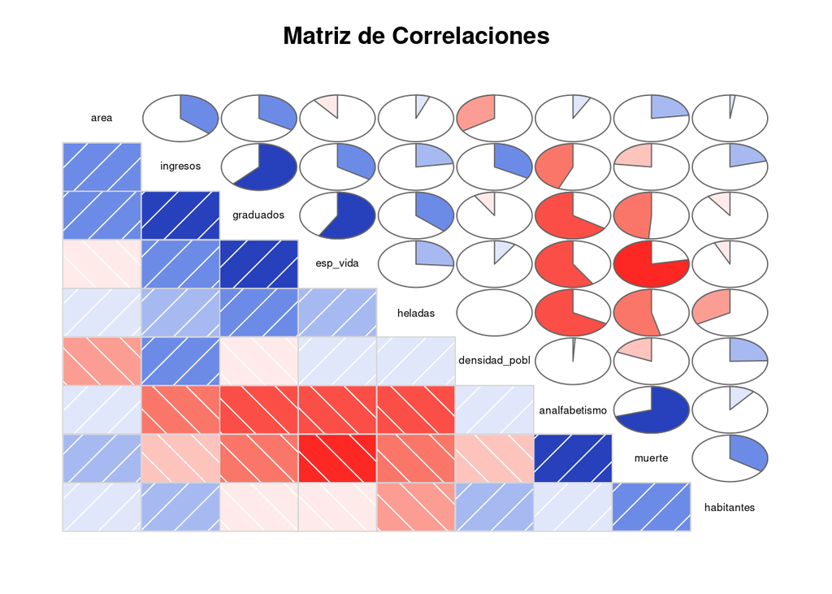

```r
library(corrgram)
library(gclus)
corrgram(datos, order=TRUE, lower.panel=panel.shade,
         upper.panel=panel.pie, text.panel=panel.txt,
         main="Matriz de Correlaciones")
```

*Otra forma:*

[figure not shown]

```r
corrgram(datos, order=NULL, lower.panel=panel.shade,
         upper.panel=NULL, text.panel=panel.txt,
         main="Matriz de Correlaciones")
```

*Asignando las correlaciones*

```r
mydata.cor = cor(datos)
knitr::kable(
mydata.cor
)
```

|  | habitantes | ingresos | analfabetismo | esp_vida | muerte | graduados | heladas | area | densidad_pobl |
| --- | --- | --- | --- | --- | --- | --- | --- | --- | --- |
| habitantes | 1.0000000 | 0.2082276 | 0.1076224 | -0.0680520 | 0.3436428 | -0.0984897 | -0.3321525 | 0.0225438 | 0.2462279 |
| ingresos | 0.2082276 | 1.0000000 | -0.4370752 | 0.3402553 | -0.2300776 | 0.6199323 | 0.2262822 | 0.3633154 | 0.3299683 |
| analfabetismo | 0.1076224 | -0.4370752 | 1.0000000 | -0.5884779 | 0.7029752 | -0.6571886 | -0.6719470 | 0.0772611 | 0.0092743 |
| esp_vida | -0.0680520 | 0.3402553 | -0.5884779 | 1.0000000 | -0.7808458 | 0.5822162 | 0.2620680 | -0.1073319 | 0.0910618 |
| muerte | 0.3436428 | -0.2300776 | 0.7029752 | -0.7808458 | 1.0000000 | -0.4879710 | -0.5388834 | 0.2283902 | -0.1850352 |
| graduados | -0.0984897 | 0.6199323 | -0.6571886 | 0.5822162 | -0.4879710 | 1.0000000 | 0.3667797 | 0.3335419 | -0.0883672 |
| heladas | -0.3321525 | 0.2262822 | -0.6719470 | 0.2620680 | -0.5388834 | 0.3667797 | 1.0000000 | 0.0592291 | 0.0022767 |
| area | 0.0225438 | 0.3633154 | 0.0772611 | -0.1073319 | 0.2283902 | 0.3335419 | 0.0592291 | 1.0000000 | -0.3413885 |
| densidad_pobl | 0.2462279 | 0.3299683 | 0.0092743 | 0.0910618 | -0.1850352 | -0.0883672 | 0.0022767 | -0.3413885 | 1.0000000 |

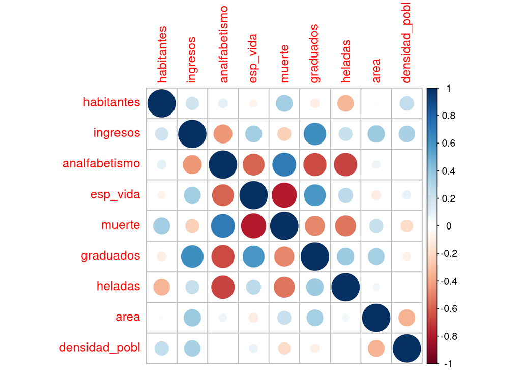

```r
# install.packages("corrplot")
library(corrplot)
corrplot(mydata.cor)
```

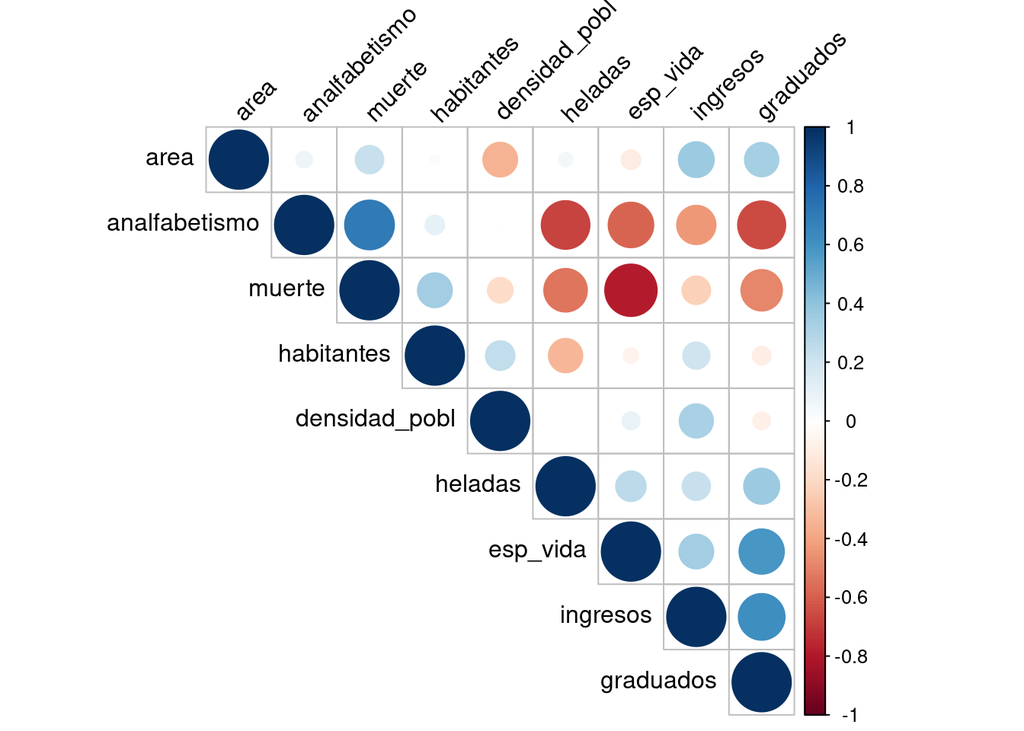

```r
corrplot(mydata.cor, type = "upper", order = "hclust", tl.col = "black", tl.srt = 45)
```

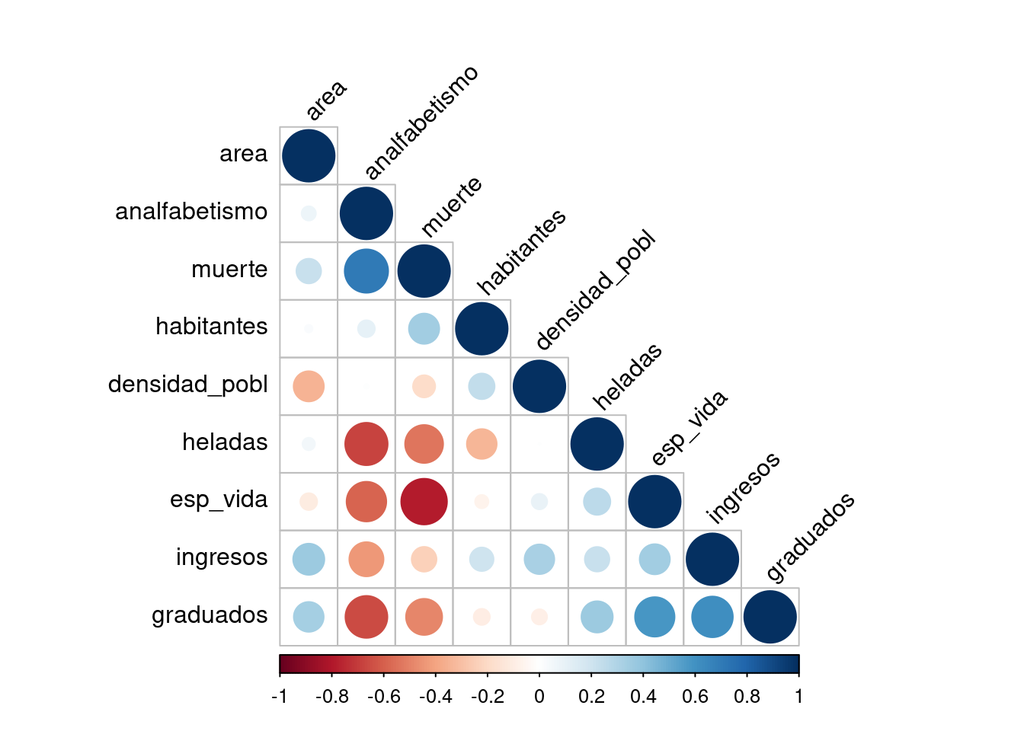

```r
corrplot(mydata.cor, type = "lower", order = "hclust", tl.col = "black", tl.srt = 45)
```

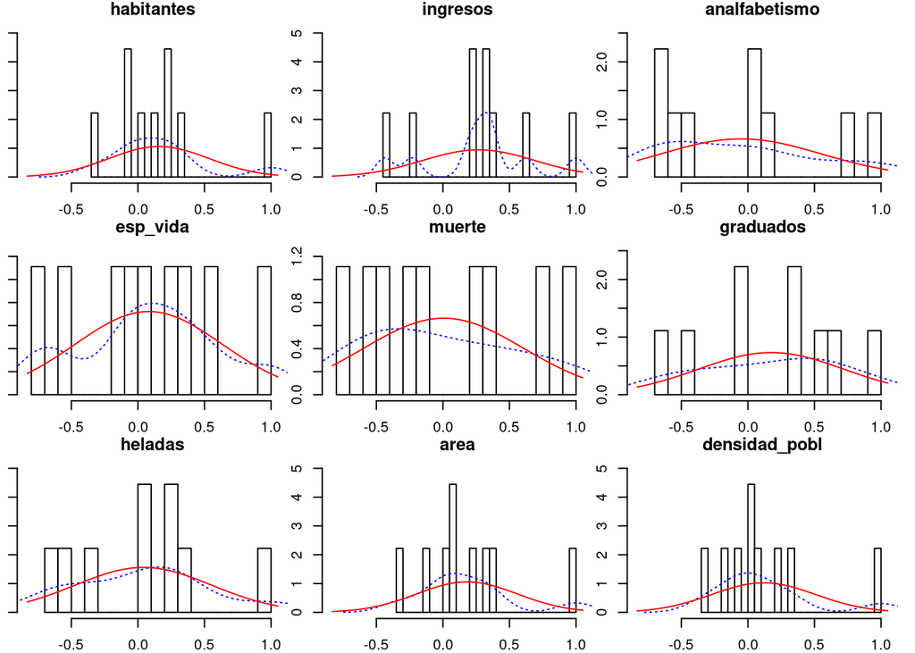

```r
library(psych)
multi.hist(x = mydata.cor, dcol = c("blue", "red"), dlty = c("dotted", "solid"))
```

*Combinando histogramas con Regresiones y Correlaciones:*

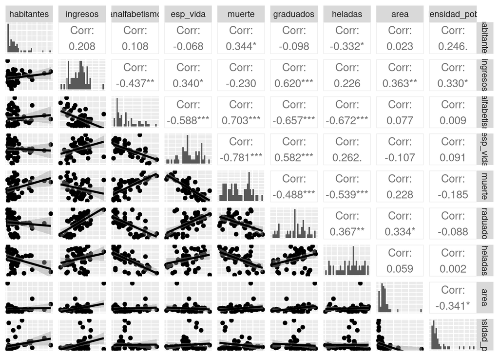

```r
library(GGally)
ggpairs(datos, lower = list(continuous = "smooth"),diag = list(continuous = "bar"), axisLabels = "none")
```

### MODELO DE REGRESIÓN LINEAL MÚLTIPLE:

*2. Generar el modelo:*

```r
modelo <- lm(esp_vida ~ habitantes + ingresos + analfabetismo + muerte + graduados + heladas + area + densidad_pobl, data = datos )

summary(modelo)
```

```
##
## Call:
## lm(formula = esp_vida ~ habitantes + ingresos + analfabetismo +
##     muerte + graduados + heladas + area + densidad_pobl, data = datos)
##
## Residuals:
##      Min       1Q   Median       3Q      Max
## -1.47514 -0.45887 -0.06352  0.59362  1.21823
##
## Coefficients:
##                 Estimate Std. Error t value Pr(>|t|)
## (Intercept)    6.995e+01  1.843e+00  37.956  < 2e-16 ***
## habitantes     6.480e-05  3.001e-05   2.159   0.0367 *
## ingresos       2.701e-04  3.087e-04   0.875   0.3867
## analfabetismo  3.029e-01  4.024e-01   0.753   0.4559
## muerte        -3.286e-01  4.941e-02  -6.652 5.12e-08 ***
## graduados      4.291e-02  2.332e-02   1.840   0.0730 .
## heladas       -4.580e-03  3.189e-03  -1.436   0.1585
## area          -1.558e-06  1.914e-06  -0.814   0.4205
## densidad_pobl -1.105e-03  7.312e-04  -1.511   0.1385
## ---
## Signif. codes:  0 '***' 0.001 '**' 0.01 '*' 0.05 '.' 0.1 ' ' 1
##
## Residual standard error: 0.7337 on 41 degrees of freedom
## Multiple R-squared:  0.7501, Adjusted R-squared:  0.7013
## F-statistic: 15.38 on 8 and 41 DF,  p-value: 3.787e-10
```

*Predicciones de Y*

```r
Predicciones<-modelo$fitted.values
# Predicciones

Y_dataset=datos$esp_vida
Y_modelad=Predicciones
Comparativo=cbind(Y_dataset, Y_modelad)
Comparativo
```

```
##                Y_dataset Y_modelad
## Alabama            69.05  68.35977
## Alaska             69.31  69.70301
## Arizona            70.55  71.52509
## Arkansas           70.66  69.54425
## California         71.71  71.85457
## Colorado           72.06  71.20429
## Connecticut        72.48  71.96438
## Delaware           70.06  71.06704
## Florida            70.66  70.61781
## Georgia            68.54  68.69550
## Hawaii             73.60  72.38177
## Idaho              71.87  71.39185
## Illinois           70.14  70.30948
## Indiana            70.88  70.86968
## Iowa               72.56  72.52812
## Kansas             72.58  71.95195
## Kentucky           70.10  69.23420
## Louisiana          68.76  69.25668
## Maine              70.39  71.86514
## Maryland           70.22  70.43356
## Massachusetts      71.83  72.06557
## Michigan           70.63  69.87605
## Minnesota          72.96  72.45362
## Mississippi        68.09  68.95961
## Missouri           70.69  70.00970
## Montana            70.56  71.30919
## Nebraska           72.60  72.26312
## Nevada             69.03  69.51082
## New Hampshire      71.23  71.84796
## New Jersey         70.93  71.10140
## New Mexico         70.32  70.09502
## New York           70.55  70.68151
## North Carolina     69.21  69.33322
## North Dakota       72.78  72.33620
## Ohio               70.82  71.04983
## Oklahoma           71.42  71.11975
## Oregon             72.13  72.35542
## Pennsylvania       70.43  71.43424
## Rhode Island       71.90  71.27399
## South Carolina     67.96  69.17325
## South Dakota       72.08  72.08382
## Tennessee          70.11  69.44971
## Texas              70.90  69.94504
## Utah               72.90  71.93372
## Vermont            71.64  71.02037
## Virginia           70.08  70.30622
## Washington         71.72  72.67871
## West Virginia      69.48  70.47298
## Wisconsin          72.48  72.15882
## Wyoming            70.29  70.87300
```

```r
Diferecias=Y_dataset-Y_modelad
Errores=cbind(Comparativo, Diferecias)
Errores
```

```
##                Y_dataset Y_modelad   Diferecias
## Alabama            69.05  68.35977  0.690233077
## Alaska             69.31  69.70301 -0.393014184
## Arizona            70.55  71.52509 -0.975085207
## Arkansas           70.66  69.54425  1.115751828
## California         71.71  71.85457 -0.144571583
## Colorado           72.06  71.20429  0.855706129
## Connecticut        72.48  71.96438  0.515615350
## Delaware           70.06  71.06704 -1.007038925
## Florida            70.66  70.61781  0.042194324
## Georgia            68.54  68.69550 -0.155498340
## Hawaii             73.60  72.38177  1.218230800
## Idaho              71.87  71.39185  0.478147392
## Illinois           70.14  70.30948 -0.169478852
## Indiana            70.88  70.86968  0.010319513
## Iowa               72.56  72.52812  0.031875031
## Kansas             72.58  71.95195  0.628047720
## Kentucky           70.10  69.23420  0.865798949
## Louisiana          68.76  69.25668 -0.496676230
## Maine              70.39  71.86514 -1.475141857
## Maryland           70.22  70.43356 -0.213558902
## Massachusetts      71.83  72.06557 -0.235568739
## Michigan           70.63  69.87605  0.753949012
## Minnesota          72.96  72.45362  0.506382389
## Mississippi        68.09  68.95961 -0.869608746
## Missouri           70.69  70.00970  0.680303836
## Montana            70.56  71.30919 -0.749187924
## Nebraska           72.60  72.26312  0.336878262
## Nevada             69.03  69.51082 -0.480816117
## New Hampshire      71.23  71.84796 -0.617962700
## New Jersey         70.93  71.10140 -0.171398845
## New Mexico         70.32  70.09502  0.224976927
## New York           70.55  70.68151 -0.131513872
## North Carolina     69.21  69.33322 -0.123216068
## North Dakota       72.78  72.33620  0.443800848
## Ohio               70.82  71.04983 -0.229827334
## Oklahoma           71.42  71.11975  0.300248058
## Oregon             72.13  72.35542 -0.225416625
## Pennsylvania       70.43  71.43424 -1.004244727
## Rhode Island       71.90  71.27399  0.626013701
## South Carolina     67.96  69.17325 -1.213253410
## South Dakota       72.08  72.08382 -0.003822235
## Tennessee          70.11  69.44971  0.660293306
## Texas              70.90  69.94504  0.954955228
## Utah               72.90  71.93372  0.966275651
## Vermont            71.64  71.02037  0.619627679
## Virginia           70.08  70.30622 -0.226217258
## Washington         71.72  72.67871 -0.958709507
## West Virginia      69.48  70.47298 -0.992977983
## Wisconsin          72.48  72.15882  0.321179837
## Wyoming            70.29  70.87300 -0.582998678
```

```r
# Según el supuesto de Mínimos Cuadrados
# La suma (promedio) de los Errores ~ 0:
SupuestErrores=mean(Errores[,3])
SupuestErrores
```

```
## [1] 0
```

*Que ocurre si eliminamos alguna de las variables predictoras?, Corramos el modelo únicamente con las variables significativas del ajuste inicial*

```r
modelo <- lm(esp_vida ~ habitantes +  muerte, data = datos )
summary(modelo)
```

```
##
## Call:
## lm(formula = esp_vida ~ habitantes + muerte, data = datos)
##
## Residuals:
##      Min       1Q   Median       3Q      Max
## -1.73194 -0.40907 -0.06544  0.48865  2.58417
##
## Coefficients:
##               Estimate Std. Error t value Pr(>|t|)
## (Intercept)  7.289e+01  2.585e-01 282.012  < 2e-16 ***
## habitantes   6.828e-05  2.742e-05   2.490   0.0164 *
## muerte      -3.123e-01  3.317e-02  -9.417 2.15e-12 ***
## ---
## Signif. codes:  0 '***' 0.001 '**' 0.01 '*' 0.05 '.' 0.1 ' ' 1
##
## Residual standard error: 0.8048 on 47 degrees of freedom
## Multiple R-squared:  0.6552, Adjusted R-squared:  0.6405
## F-statistic: 44.66 on 2 and 47 DF,  p-value: 1.357e-11
```

*Diagnóstico del Modelo del Modelo Inicial (Modelo con todas las variables predictoras):*

```r
modelo <- lm(esp_vida ~ habitantes + ingresos + analfabetismo + muerte + graduados + heladas + area + densidad_pobl, data = datos )


# Coeficientes del Modelo (bettas)
coefficients(modelo)
```

```
##   (Intercept)    habitantes      ingresos analfabetismo        muerte
##  6.995061e+01  6.480191e-05  2.700719e-04  3.028607e-01 -3.286480e-01
##     graduados       heladas          area densidad_pobl
##  4.290767e-02 -4.580195e-03 -1.557759e-06 -1.104781e-03
```

```r
# I.C. de la estimación de los bettas
confint(modelo, level=0.95)
```

```
##                       2.5 %        97.5 %
## (Intercept)    6.622872e+01  7.367251e+01
## habitantes     4.192906e-06  1.254109e-04
## ingresos      -3.533399e-04  8.934837e-04
## analfabetismo -5.097129e-01  1.115434e+00
## muerte        -4.284249e-01 -2.288711e-01
## graduados     -4.184247e-03  8.999959e-02
## heladas       -1.102098e-02  1.860585e-03
## area          -5.423922e-06  2.308404e-06
## densidad_pobl -2.581440e-03  3.718781e-04
```

```r
# Predicciones
fitted(modelo)
```

```
##        Alabama         Alaska        Arizona       Arkansas     California
##       68.35977       69.70301       71.52509       69.54425       71.85457
##       Colorado    Connecticut       Delaware        Florida        Georgia
##       71.20429       71.96438       71.06704       70.61781       68.69550
##         Hawaii          Idaho       Illinois        Indiana           Iowa
##       72.38177       71.39185       70.30948       70.86968       72.52812
##         Kansas       Kentucky      Louisiana          Maine       Maryland
##       71.95195       69.23420       69.25668       71.86514       70.43356
##  Massachusetts       Michigan      Minnesota    Mississippi       Missouri
##       72.06557       69.87605       72.45362       68.95961       70.00970
##        Montana       Nebraska         Nevada  New Hampshire     New Jersey
##       71.30919       72.26312       69.51082       71.84796       71.10140
##     New Mexico       New York North Carolina   North Dakota           Ohio
##       70.09502       70.68151       69.33322       72.33620       71.04983
##       Oklahoma         Oregon   Pennsylvania   Rhode Island South Carolina
##       71.11975       72.35542       71.43424       71.27399       69.17325
##   South Dakota      Tennessee          Texas           Utah        Vermont
##       72.08382       69.44971       69.94504       71.93372       71.02037
##       Virginia     Washington  West Virginia      Wisconsin        Wyoming
##       70.30622       72.67871       70.47298       72.15882       70.87300
```

```r
# residuales
residuals(modelo)
```

```
##        Alabama         Alaska        Arizona       Arkansas     California
##    0.690233077   -0.393014184   -0.975085207    1.115751828   -0.144571583
##       Colorado    Connecticut       Delaware        Florida        Georgia
##    0.855706129    0.515615350   -1.007038925    0.042194324   -0.155498340
##         Hawaii          Idaho       Illinois        Indiana           Iowa
##    1.218230800    0.478147392   -0.169478852    0.010319513    0.031875031
##         Kansas       Kentucky      Louisiana          Maine       Maryland
##    0.628047720    0.865798949   -0.496676230   -1.475141857   -0.213558902
##  Massachusetts       Michigan      Minnesota    Mississippi       Missouri
##   -0.235568739    0.753949012    0.506382389   -0.869608746    0.680303836
##        Montana       Nebraska         Nevada  New Hampshire     New Jersey
##   -0.749187924    0.336878262   -0.480816117   -0.617962700   -0.171398845
##     New Mexico       New York North Carolina   North Dakota           Ohio
##    0.224976927   -0.131513872   -0.123216068    0.443800848   -0.229827334
##       Oklahoma         Oregon   Pennsylvania   Rhode Island South Carolina
##    0.300248058   -0.225416625   -1.004244727    0.626013701   -1.213253410
##   South Dakota      Tennessee          Texas           Utah        Vermont
##   -0.003822235    0.660293306    0.954955228    0.966275651    0.619627679
##       Virginia     Washington  West Virginia      Wisconsin        Wyoming
##   -0.226217258   -0.958709507   -0.992977983    0.321179837   -0.582998678
```

```r
# Tabla ANOVA
knitr::kable(
anova(modelo)
)
```

|  | Df | Sum Sq | Mean Sq | F value | Pr(>F) |
| --- | --- | --- | --- | --- | --- |
| habitantes | 1 | 0.4089187 | 0.4089187 | 0.7597160 | 0.3884929 |
| ingresos | 1 | 11.5946306 | 11.5946306 | 21.5412666 | 0.0000353 |
| analfabetismo | 1 | 19.4207309 | 19.4207309 | 36.0811100 | 0.0000004 |
| muerte | 1 | 27.4288381 | 27.4288381 | 50.9590976 | 0.0000000 |
| graduados | 1 | 4.0988911 | 4.0988911 | 7.6151892 | 0.0086125 |
| heladas | 1 | 2.0487679 | 2.0487679 | 3.8063356 | 0.0579156 |
| area | 1 | 0.0010866 | 0.0010866 | 0.0020187 | 0.9643811 |
| densidad_pobl | 1 | 1.2288046 | 1.2288046 | 2.2829540 | 0.1384722 |
| Residuals | 41 | 22.0683335 | 0.5382520 | NA | NA |

```r
# La Matriz de Covarianzas del Modelo
knitr::kable(
vcov(modelo)
)
```

|  | (Intercept) | habitantes | ingresos | analfabetismo | muerte | graduados | heladas | area | densidad_pobl |
| --- | --- | --- | --- | --- | --- | --- | --- | --- | --- |
| (Intercept) | 3.3964314 | -8.5e-06 | -0.0002757 | -0.5507936 | -0.0081216 | -0.0245238 | -0.0034130 | 2.3e-06 | 0.0004804 |
| habitantes | -0.0000085 | 0.0e+00 | 0.0000000 | 0.0000043 | -0.0000006 | 0.0000001 | 0.0000000 | 0.0e+00 | 0.0000000 |
| ingresos | -0.0002757 | 0.0e+00 | 0.0000001 | 0.0000427 | -0.0000030 | -0.0000027 | 0.0000001 | 0.0e+00 | -0.0000001 |
| analfabetismo | -0.5507936 | 4.3e-06 | 0.0000427 | 0.1618900 | -0.0087810 | 0.0034149 | 0.0007907 | -4.0e-07 | -0.0001302 |
| muerte | -0.0081216 | -6.0e-07 | -0.0000030 | -0.0087810 | 0.0024409 | 0.0002771 | 0.0000003 | 0.0e+00 | 0.0000133 |
| graduados | -0.0245238 | 1.0e-07 | -0.0000027 | 0.0034149 | 0.0002771 | 0.0005437 | 0.0000174 | 0.0e+00 | 0.0000029 |
| heladas | -0.0034130 | 0.0e+00 | 0.0000001 | 0.0007907 | 0.0000003 | 0.0000174 | 0.0000102 | 0.0e+00 | -0.0000006 |
| area | 0.0000023 | 0.0e+00 | 0.0000000 | -0.0000004 | 0.0000000 | 0.0000000 | 0.0000000 | 0.0e+00 | 0.0000000 |
| densidad_pobl | 0.0004804 | 0.0e+00 | -0.0000001 | -0.0001302 | 0.0000133 | 0.0000029 | -0.0000006 | 0.0e+00 | 0.0000005 |

*Gráficos Diagnósticos:*

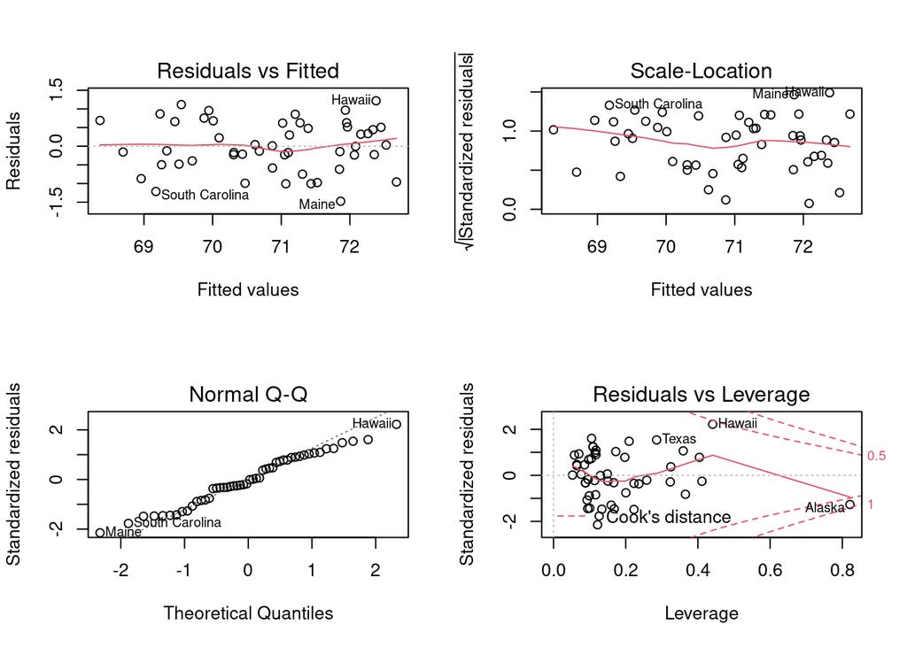

```r
layout(matrix(c(1,2,3,4),2,2)) # División de la venta de gráficos
plot(modelo)
```

*Gráfico residuos estudentizados frente a valores ajustados por el modelo:*

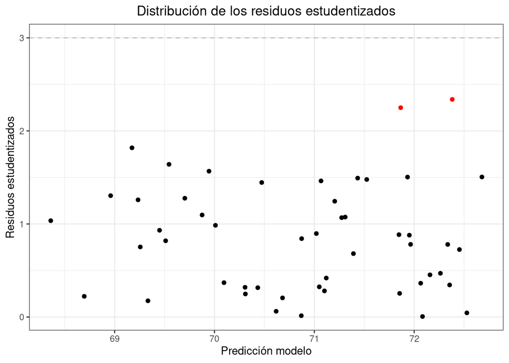

```r
library(ggplot2)
ggplot(data = datos, aes(x = predict(modelo),
                        y = abs(rstudent(modelo))))+
  geom_hline(yintercept = 3, color = "grey", linetype = "dashed")+

# se identifican en rojo las observaciones con residuos estudentizados
geom_point(aes(color = ifelse(abs(rstudent(modelo)) > 2, "red", "black")))+
  scale_color_identity()+
  labs(title = "Distribución de los residuos estudentizados",
       x = "Predicción modelo",
       y = "Residuos estudentizados")+
  theme_bw() + theme(plot.title = element_text(hjust = 0.5))
```

*Detección de los residuos estandarizados > 3 considerados como outliers*

```r
which(rstudent(modelo) > 3)
```

```
## named integer(0)
```

```r
# Outliers
# library(car) # En R_3.5
# outlierTest(modelo)

# install.packages("outliers")
library(outliers)
test <- grubbs.test(modelo$residuals )
test
```

```
##
##  Grubbs test for one outlier
##
## data:  modelo$residuals
## G.Maine = 2.19810, U = 0.89938, p-value = 0.6199
## alternative hypothesis: lowest value -1.47514185671001 is an outlier
```

La prueba de Grubbs permite detectar si el valor más alto o más bajo en un conjunto de datos es un valor atípico.

La prueba de Grubbs detecta un valor atípico a la vez (valor más alto o más bajo), por lo que las hipótesis nula y alternativa son las siguientes:

```
H0: el valor más alto no es un valor atípico
H1: el valor más alto es un valor atípico
```

si queremos probar el valor más alto, o:

```
H0: el valor más bajo no es un valor atípico
H1: el valor más bajo es un valor atípico
```

si queremos probar el valor más bajo.

Como para cualquier prueba estadística, si el valor p es menor que el umbral de significancia elegido (generalmente α = 0.05), entonces se rechaza la hipótesis nula y concluiremos que el valor más bajo / más alto es un valor atípico. Por el contrario, si el valor p es mayor o igual que el nivel de significancia, no se rechaza la hipótesis nula, y concluiremos que, con base en los datos, no rechazamos la hipótesis de que el valor más bajo / más alto no es un valor atípico.

Tenga en cuenta que la prueba de Grubbs no es apropiada para un tamaño de muestra de 6 o menos (n≤6).

*COLINEALIDAD - FACTOR DE INFLACIÓN DE LA VARIANZA:*

*VIF=1/(1-R^2) donde R^2 es el coeficiente de determinación de la regresión del j-ésimo regresor sobre el resto. El valor mínimo de VIF es 1 y un VIF>10 puede indicar la existencia colinealidad (o >5 siend estricto…)*

```r
library(caret)
library(MASS)
library(tidyverse)
car::vif(modelo)
```

```
##    habitantes      ingresos analfabetismo        muerte     graduados
##      1.634268      3.275340      5.475516      3.028169      3.229221
##       heladas          area densidad_pobl
##      2.501893      2.429078      2.377250
```

*Autocorrelación: Estadístico Durbyn Whatson:*

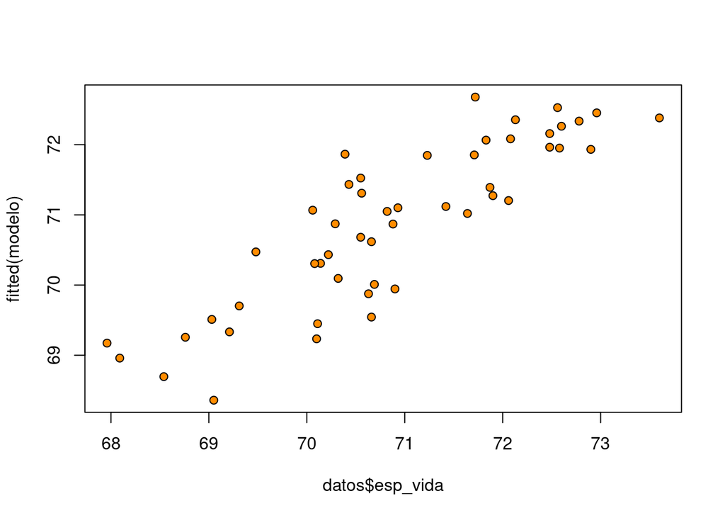

```r
# graficamos el nuestros valores estimados
plot(datos$esp_vida, fitted(modelo), cex = 1, pch = 21, bg = "darkorange", col = "black")
lines(fitted(modelo))
```

*Test de validación de autocorrelación, a través del estadístico de Durbyn & Whatson*

*Las Hipótesis en juego son:*

*Ho: La autocorrelación verdadera es igual a 0* *Ha: La autocorrelación verdadera es mayor que 0*

*En este caso se desea NO RECHAZAR LA HIPOTESIS NULA*

```r
# Cargamos el paquete lmtest para realizar la prueba Durbin-Watson
library(lmtest)
dwtest(modelo)
```

```
##
##  Durbin-Watson test
##
## data:  modelo
## DW = 1.9653, p-value = 0.4526
## alternative hypothesis: true autocorrelation is greater than 0
```

*UN PEQUEÑO EJEMPLO DE UN AJUSTE DE REGRESIÓN 3D (Dos variables idependientes X’s que expliquen a Y):*

```r
library(rgl)
modelo2 <- lm(esp_vida ~ muerte + graduados, data=datos)

# predicción del modelo2
summary(modelo2)
```

```
##
## Call:
## lm(formula = esp_vida ~ muerte + graduados, data = datos)
##
## Residuals:
##      Min       1Q   Median       3Q      Max
## -1.66758 -0.41801  0.05602  0.55913  2.05625
##
## Coefficients:
##             Estimate Std. Error t value Pr(>|t|)
## (Intercept) 70.29708    1.01567  69.213  < 2e-16 ***
## muerte      -0.23709    0.03529  -6.719 2.18e-08 ***
## graduados    0.04389    0.01613   2.721  0.00909 **
## ---
## Signif. codes:  0 '***' 0.001 '**' 0.01 '*' 0.05 '.' 0.1 ' ' 1
##
## Residual standard error: 0.7959 on 47 degrees of freedom
## Multiple R-squared:  0.6628, Adjusted R-squared:  0.6485
## F-statistic:  46.2 on 2 and 47 DF,  p-value: 8.016e-12
```

```r
# Haciendo la Grilla
plotdata2 <- expand.grid(graduados=seq(34,70,by=2),muerte=seq(1,16,by=1))
plotdata2$pred1 <- predict(modelo2,newdata=plotdata2)


# Graficando la Regresión Múltiple en 3D
with(datos,plot3d(graduados, muerte, esp_vida,  col="blue", size=1, type="s"))
with(plotdata2,surface3d(unique(graduados),unique(muerte),pred1,
                       alpha=0.5,front="line", back="line"))
```

[output not shown]

### Algorítmo automático de selección

En este caso se van a emplear la estrategia de stepwise mixto.  
El estadístico empleado para determinar la calidad del modelo va a ser Akaike(AIC). En este sentido, el modelo con el menor AIC será el mejor modelo:

```r
step(object = modelo, direction = "both", trace = 1)
```

```
## Start:  AIC=-22.89
## esp_vida ~ habitantes + ingresos + analfabetismo + muerte + graduados +
##     heladas + area + densidad_pobl
##
##                 Df Sum of Sq    RSS     AIC
## - analfabetismo  1    0.3050 22.373 -24.208
## - area           1    0.3564 22.425 -24.093
## - ingresos       1    0.4120 22.480 -23.969
## <none>                       22.068 -22.894
## - heladas        1    1.1102 23.178 -22.440
## - densidad_pobl  1    1.2288 23.297 -22.185
## - graduados      1    1.8225 23.891 -20.926
## - habitantes     1    2.5095 24.578 -19.509
## - muerte         1   23.8173 45.886  11.707
##
## Step:  AIC=-24.21
## esp_vida ~ habitantes + ingresos + muerte + graduados + heladas +
##     area + densidad_pobl
##
##                 Df Sum of Sq    RSS     AIC
## - area           1    0.1427 22.516 -25.890
## - ingresos       1    0.2316 22.605 -25.693
## <none>                       22.373 -24.208
## - densidad_pobl  1    0.9286 23.302 -24.174
## - graduados      1    1.5218 23.895 -22.918
## + analfabetismo  1    0.3050 22.068 -22.894
## - habitantes     1    2.2047 24.578 -21.509
## - heladas        1    3.1324 25.506 -19.656
## - muerte         1   26.7071 49.080  13.072
##
## Step:  AIC=-25.89
## esp_vida ~ habitantes + ingresos + muerte + graduados + heladas +
##     densidad_pobl
##
##                 Df Sum of Sq    RSS     AIC
## - ingresos       1     0.132 22.648 -27.598
## - densidad_pobl  1     0.786 23.302 -26.174
## <none>                       22.516 -25.890
## - graduados      1     1.424 23.940 -24.824
## + area           1     0.143 22.373 -24.208
```

[output cut: 17 more lines]

```
## - muerte         1    33.626 56.274  15.910
##
## Step:  AIC=-28.16
## esp_vida ~ habitantes + muerte + graduados + heladas
##
##                 Df Sum of Sq    RSS     AIC
## <none>                       23.308 -28.161
## + densidad_pobl  1     0.660 22.648 -27.598
## + ingresos       1     0.006 23.302 -26.174
## + analfabetismo  1     0.004 23.304 -26.170
## + area           1     0.001 23.307 -26.163
## - habitantes     1     2.064 25.372 -25.920
## - heladas        1     3.122 26.430 -23.877
## - graduados      1     5.112 28.420 -20.246
## - muerte         1    34.816 58.124  15.528
```

```
##
## Call:
## lm(formula = esp_vida ~ habitantes + muerte + graduados + heladas,
##     data = datos)
##
## Coefficients:
## (Intercept)   habitantes       muerte    graduados      heladas
##   7.103e+01    5.014e-05   -3.001e-01    4.658e-02   -5.943e-03
```

*Elección del Modelo Final* En Conclusión: El mejor modelo resultante del proceso de selección ha sido:

```r
modelo <- (lm(formula = esp_vida ~ habitantes + muerte + graduados +
                heladas, data = datos))

summary(modelo)
```

```
##
## Call:
## lm(formula = esp_vida ~ habitantes + muerte + graduados + heladas,
##     data = datos)
##
## Residuals:
##      Min       1Q   Median       3Q      Max
## -1.47095 -0.53464 -0.03701  0.57621  1.50683
##
## Coefficients:
##               Estimate Std. Error t value Pr(>|t|)
## (Intercept)  7.103e+01  9.529e-01  74.542  < 2e-16 ***
## habitantes   5.014e-05  2.512e-05   1.996  0.05201 .
## muerte      -3.001e-01  3.661e-02  -8.199 1.77e-10 ***
## graduados    4.658e-02  1.483e-02   3.142  0.00297 **
## heladas     -5.943e-03  2.421e-03  -2.455  0.01802 *
## ---
## Signif. codes:  0 '***' 0.001 '**' 0.01 '*' 0.05 '.' 0.1 ' ' 1
##
## Residual standard error: 0.7197 on 45 degrees of freedom
## Multiple R-squared:  0.736,  Adjusted R-squared:  0.7126
## F-statistic: 31.37 on 4 and 45 DF,  p-value: 1.696e-12
```